# EDA_ON_GLOBAL_TERRORISM

## Monthly Intership Program for Professionals@THE CODERS READY

## Data Science and Business Analytics

## Name:Ritik Mehra

## Trainee Intern at CODERS READY

## Batch:October 2022

## Task 1:Exploratory Data Analysis - Dataset Global Terrorism

### In this project we are trying to trace hot zones of terrorism and other security issues with the help of Exploratory Data Analysis (EDA).

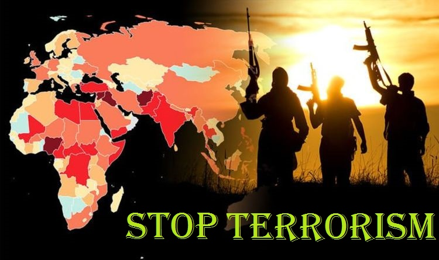

### Exploratory Data Analysis (EDA):

### EDA is a technique that data professionals can be use to understand a datasets before they start to model it.

```python
#importing libraries
import pandas as pd               #for analyse & manipulation of data.
import seaborn as sns             #Both matplotlib and seaborn are used for visualizations.
import matplotlib.pyplot as plt
import numpy as np               #For arraya
from scipy.optimize import curve_fit
import warnings
warnings.filterwarnings('ignore')
```

```python
csv_data_path = "C:/Users/CODERS READY/globalterrorism.csv"  #Location path of the file.
```

```python
globalterrorism = pd.read_csv(csv_data_path)  #reading the data file means import the csv file.
```

```python
rm = pd.DataFrame(globalterrorism)        #creating data frame.
rm
```

|  | eventid | iyear | imonth | iday | approxdate | extended | resolution | country | country_txt | region | ... | addnotes | scite1 | scite2 | scite3 | dbsource | INT_LOG | INT_IDEO | INT_MISC | INT_ANY | related |
| --- | --- | --- | --- | --- | --- | --- | --- | --- | --- | --- | --- | --- | --- | --- | --- | --- | --- | --- | --- | --- | --- |
| 0 | 1.970000e+11 | 1970 | 7 | 2 | NaN | 0 | NaN | 58 | Dominican Republic | 2 | ... | NaN | NaN | NaN | NaN | PGIS | 0 | 0 | 0 | 0 | NaN |
| 1 | 1.970000e+11 | 1970 | 0 | 0 | NaN | 0 | NaN | 130 | Mexico | 1 | ... | NaN | NaN | NaN | NaN | PGIS | 0 | 1 | 1 | 1 | NaN |
| 2 | 1.970010e+11 | 1970 | 1 | 0 | NaN | 0 | NaN | 160 | Philippines | 5 | ... | NaN | NaN | NaN | NaN | PGIS | -9 | -9 | 1 | 1 | NaN |
| 3 | 1.970010e+11 | 1970 | 1 | 0 | NaN | 0 | NaN | 78 | Greece | 8 | ... | NaN | NaN | NaN | NaN | PGIS | -9 | -9 | 1 | 1 | NaN |
| 4 | 1.970010e+11 | 1970 | 1 | 0 | NaN | 0 | NaN | 101 | Japan | 4 | ... | NaN | NaN | NaN | NaN | PGIS | -9 | -9 | 1 | 1 | NaN |
| ... | ... | ... | ... | ... | ... | ... | ... | ... | ... | ... | ... | ... | ... | ... | ... | ... | ... | ... | ... | ... | ... |
| 181686 | 2.017120e+11 | 2017 | 12 | 31 | NaN | 0 | NaN | 182 | Somalia | 11 | ... | NaN | "Somalia: Al-Shabaab Militants Attack Army Che... | "Highlights: Somalia Daily Media Highlights 2 ... | "Highlights: Somalia Daily Media Highlights 1 ... | START Primary Collection | 0 | 0 | 0 | 0 | NaN |
| 181687 | 2.017120e+11 | 2017 | 12 | 31 | NaN | 0 | NaN | 200 | Syria | 10 | ... | NaN | "Putin's 'victory' in Syria has turned into a ... | "Two Russian soldiers killed at Hmeymim base i... | "Two Russian servicemen killed in Syria mortar... | START Primary Collection | -9 | -9 | 1 | 1 | NaN |
| 181688 | 2.017120e+11 | 2017 | 12 | 31 | NaN | 0 | NaN | 160 | Philippines | 5 | ... | NaN | "Maguindanao clashes trap tribe members," Phil... | NaN | NaN | START Primary Collection | 0 | 0 | 0 | 0 | NaN |
| 181689 | 2.017120e+11 | 2017 | 12 | 31 | NaN | 0 | NaN | 92 | India | 6 | ... | NaN | "Trader escapes grenade attack in Imphal," Bus... | NaN | NaN | START Primary Collection | -9 | -9 | 0 | -9 | NaN |
| 181690 | 2.017120e+11 | 2017 | 12 | 31 | NaN | 0 | NaN | 160 | Philippines | 5 | ... | NaN | "Security tightened in Cotabato following IED ... | "Security tightened in Cotabato City," Manila ... | NaN | START Primary Collection | -9 | -9 | 0 | -9 | NaN |

181691 rows × 135 columns

```python
print("There are {} rows and {} columns in the dataset.".format(rm.shape[0],rm.shape[1])) #showing total no. of rows and columns
```

```
There are 181691 rows and 135 columns in the dataset.
```

```python
rm.columns
```

```
Index(['eventid', 'iyear', 'imonth', 'iday', 'approxdate', 'extended',
       'resolution', 'country', 'country_txt', 'region',
       ...
       'addnotes', 'scite1', 'scite2', 'scite3', 'dbsource', 'INT_LOG',
       'INT_IDEO', 'INT_MISC', 'INT_ANY', 'related'],
      dtype='object', length=135)
```

```python
No_of_colms = rm.columns.nunique()
print("There are total %d columns in the dataset."%No_of_colms)
```

```
There are total 135 columns in the dataset.
```

Renaming some columns.

```python
rm = rm.rename(columns={'eventid':'Event id','iyear':'Year','imonth':'Month','iday':'Day','approxdate':'Approx date','country_txt':'Country','region_txt':'Region','provstate':'State','city':'City','attacktype1_txt':'Attack_type','targtype1_txt':'Target_type','targsubtype1_txt':'Target_subtype','gname':'Gang_name','weaptype1_txt':'Weapon_type'})
rm
```

|  | Event id | Year | Month | Day | Approx date | extended | resolution | country | Country | region | ... | addnotes | scite1 | scite2 | scite3 | dbsource | INT_LOG | INT_IDEO | INT_MISC | INT_ANY | related |
| --- | --- | --- | --- | --- | --- | --- | --- | --- | --- | --- | --- | --- | --- | --- | --- | --- | --- | --- | --- | --- | --- |
| 0 | 1.970000e+11 | 1970 | 7 | 2 | NaN | 0 | NaN | 58 | Dominican Republic | 2 | ... | NaN | NaN | NaN | NaN | PGIS | 0 | 0 | 0 | 0 | NaN |
| 1 | 1.970000e+11 | 1970 | 0 | 0 | NaN | 0 | NaN | 130 | Mexico | 1 | ... | NaN | NaN | NaN | NaN | PGIS | 0 | 1 | 1 | 1 | NaN |
| 2 | 1.970010e+11 | 1970 | 1 | 0 | NaN | 0 | NaN | 160 | Philippines | 5 | ... | NaN | NaN | NaN | NaN | PGIS | -9 | -9 | 1 | 1 | NaN |
| 3 | 1.970010e+11 | 1970 | 1 | 0 | NaN | 0 | NaN | 78 | Greece | 8 | ... | NaN | NaN | NaN | NaN | PGIS | -9 | -9 | 1 | 1 | NaN |
| 4 | 1.970010e+11 | 1970 | 1 | 0 | NaN | 0 | NaN | 101 | Japan | 4 | ... | NaN | NaN | NaN | NaN | PGIS | -9 | -9 | 1 | 1 | NaN |
| ... | ... | ... | ... | ... | ... | ... | ... | ... | ... | ... | ... | ... | ... | ... | ... | ... | ... | ... | ... | ... | ... |
| 181686 | 2.017120e+11 | 2017 | 12 | 31 | NaN | 0 | NaN | 182 | Somalia | 11 | ... | NaN | "Somalia: Al-Shabaab Militants Attack Army Che... | "Highlights: Somalia Daily Media Highlights 2 ... | "Highlights: Somalia Daily Media Highlights 1 ... | START Primary Collection | 0 | 0 | 0 | 0 | NaN |
| 181687 | 2.017120e+11 | 2017 | 12 | 31 | NaN | 0 | NaN | 200 | Syria | 10 | ... | NaN | "Putin's 'victory' in Syria has turned into a ... | "Two Russian soldiers killed at Hmeymim base i... | "Two Russian servicemen killed in Syria mortar... | START Primary Collection | -9 | -9 | 1 | 1 | NaN |
| 181688 | 2.017120e+11 | 2017 | 12 | 31 | NaN | 0 | NaN | 160 | Philippines | 5 | ... | NaN | "Maguindanao clashes trap tribe members," Phil... | NaN | NaN | START Primary Collection | 0 | 0 | 0 | 0 | NaN |
| 181689 | 2.017120e+11 | 2017 | 12 | 31 | NaN | 0 | NaN | 92 | India | 6 | ... | NaN | "Trader escapes grenade attack in Imphal," Bus... | NaN | NaN | START Primary Collection | -9 | -9 | 0 | -9 | NaN |
| 181690 | 2.017120e+11 | 2017 | 12 | 31 | NaN | 0 | NaN | 160 | Philippines | 5 | ... | NaN | "Security tightened in Cotabato following IED ... | "Security tightened in Cotabato City," Manila ... | NaN | START Primary Collection | -9 | -9 | 0 | -9 | NaN |

181691 rows × 135 columns

### NEW DATAFRAME(HERE FILTERATE DATA ACC. TO REQ.)

```python
rm = rm[['Year','Month','Day','Country','Region','State','City','Attack_type','Target_type','Target_subtype','Gang_name','Weapon_type']]
rm
```

|  | Year | Month | Day | Country | Region | State | City | Attack_type | Target_type | Target_subtype | Gang_name | Weapon_type |
| --- | --- | --- | --- | --- | --- | --- | --- | --- | --- | --- | --- | --- |
| 0 | 1970 | 7 | 2 | Dominican Republic | Central America & Caribbean | NaN | Santo Domingo | Assassination | Private Citizens & Property | Named Civilian | MANO-D | Unknown |
| 1 | 1970 | 0 | 0 | Mexico | North America | Federal | Mexico city | Hostage Taking (Kidnapping) | Government (Diplomatic) | Diplomatic Personnel (outside of embassy, cons... | 23rd of September Communist League | Unknown |
| 2 | 1970 | 1 | 0 | Philippines | Southeast Asia | Tarlac | Unknown | Assassination | Journalists & Media | Radio Journalist/Staff/Facility | Unknown | Unknown |
| 3 | 1970 | 1 | 0 | Greece | Western Europe | Attica | Athens | Bombing/Explosion | Government (Diplomatic) | Embassy/Consulate | Unknown | Explosives |
| 4 | 1970 | 1 | 0 | Japan | East Asia | Fukouka | Fukouka | Facility/Infrastructure Attack | Government (Diplomatic) | Embassy/Consulate | Unknown | Incendiary |
| ... | ... | ... | ... | ... | ... | ... | ... | ... | ... | ... | ... | ... |
| 181686 | 2017 | 12 | 31 | Somalia | Sub-Saharan Africa | Middle Shebelle | Ceelka Geelow | Armed Assault | Military | Military Checkpoint | Al-Shabaab | Firearms |
| 181687 | 2017 | 12 | 31 | Syria | Middle East & North Africa | Lattakia | Jableh | Bombing/Explosion | Military | Military Barracks/Base/Headquarters/Checkpost | Muslim extremists | Explosives |
| 181688 | 2017 | 12 | 31 | Philippines | Southeast Asia | Maguindanao | Kubentog | Facility/Infrastructure Attack | Private Citizens & Property | House/Apartment/Residence | Bangsamoro Islamic Freedom Movement (BIFM) | Incendiary |
| 181689 | 2017 | 12 | 31 | India | South Asia | Manipur | Imphal | Bombing/Explosion | Government (General) | Government Building/Facility/Office | Unknown | Explosives |
| 181690 | 2017 | 12 | 31 | Philippines | Southeast Asia | Maguindanao | Cotabato City | Bombing/Explosion | Unknown | NaN | Unknown | Explosives |

181691 rows × 12 columns

# SHOWING NO. OF NAN VALUES IN COLUMNS.

```python
rm.isnull().sum()          #nan values is in state, city and also in Target_subtype column.
```

```
Year                  0
Month                 0
Day                   0
Country               0
Region                0
State               421
City                434
Attack_type           0
Target_type           0
Target_subtype    10373
Gang_name             0
Weapon_type           0
dtype: int64
```

## FILLING NAN VALUES.

```python
rm['State']=rm['State'].fillna('Unknown')
```

```python
rm['City']=rm['City'].fillna('Unknown')
```

```python
rm['Target_subtype'] = rm['Target_subtype'].fillna('others')
```

```python
rm.isnull().sum()        #there is not any NAN values in the columns.
```

```
Year              0
Month             0
Day               0
Country           0
Region            0
State             0
City              0
Attack_type       0
Target_type       0
Target_subtype    0
Gang_name         0
Weapon_type       0
dtype: int64
```

```python
print("Now there are {} rows and {} columns in the dataset.".format(rm.shape[0],rm.shape[1])) #new data set.
```

```
Now there are 181691 rows and 12 columns in the dataset.
```

```python
rm.columns.unique()
```

```
Index(['Year', 'Month', 'Day', 'Country', 'Region', 'State', 'City',
       'Attack_type', 'Target_type', 'Target_subtype', 'Gang_name',
       'Weapon_type'],
      dtype='object')
```

```python
rm.head()
```

|  | Year | Month | Day | Country | Region | State | City | Attack_type | Target_type | Target_subtype | Gang_name | Weapon_type |
| --- | --- | --- | --- | --- | --- | --- | --- | --- | --- | --- | --- | --- |
| 0 | 1970 | 7 | 2 | Dominican Republic | Central America & Caribbean | Unknown | Santo Domingo | Assassination | Private Citizens & Property | Named Civilian | MANO-D | Unknown |
| 1 | 1970 | 0 | 0 | Mexico | North America | Federal | Mexico city | Hostage Taking (Kidnapping) | Government (Diplomatic) | Diplomatic Personnel (outside of embassy, cons... | 23rd of September Communist League | Unknown |
| 2 | 1970 | 1 | 0 | Philippines | Southeast Asia | Tarlac | Unknown | Assassination | Journalists & Media | Radio Journalist/Staff/Facility | Unknown | Unknown |
| 3 | 1970 | 1 | 0 | Greece | Western Europe | Attica | Athens | Bombing/Explosion | Government (Diplomatic) | Embassy/Consulate | Unknown | Explosives |
| 4 | 1970 | 1 | 0 | Japan | East Asia | Fukouka | Fukouka | Facility/Infrastructure Attack | Government (Diplomatic) | Embassy/Consulate | Unknown | Incendiary |

```python
rm.info()
```

```
<class 'pandas.core.frame.DataFrame'>
RangeIndex: 181691 entries, 0 to 181690
Data columns (total 12 columns):
 #   Column          Non-Null Count   Dtype
---  ------          --------------   -----
 0   Year            181691 non-null  int64
 1   Month           181691 non-null  int64
 2   Day             181691 non-null  int64
 3   Country         181691 non-null  object
 4   Region          181691 non-null  object
 5   State           181691 non-null  object
 6   City            181691 non-null  object
 7   Attack_type     181691 non-null  object
 8   Target_type     181691 non-null  object
 9   Target_subtype  181691 non-null  object
 10  Gang_name       181691 non-null  object
 11  Weapon_type     181691 non-null  object
dtypes: int64(3), object(9)
memory usage: 10.4+ MB
```

```python
rm.tail()
```

|  | Year | Month | Day | Country | Region | State | City | Attack_type | Target_type | Target_subtype | Gang_name | Weapon_type |
| --- | --- | --- | --- | --- | --- | --- | --- | --- | --- | --- | --- | --- |
| 181686 | 2017 | 12 | 31 | Somalia | Sub-Saharan Africa | Middle Shebelle | Ceelka Geelow | Armed Assault | Military | Military Checkpoint | Al-Shabaab | Firearms |
| 181687 | 2017 | 12 | 31 | Syria | Middle East & North Africa | Lattakia | Jableh | Bombing/Explosion | Military | Military Barracks/Base/Headquarters/Checkpost | Muslim extremists | Explosives |
| 181688 | 2017 | 12 | 31 | Philippines | Southeast Asia | Maguindanao | Kubentog | Facility/Infrastructure Attack | Private Citizens & Property | House/Apartment/Residence | Bangsamoro Islamic Freedom Movement (BIFM) | Incendiary |
| 181689 | 2017 | 12 | 31 | India | South Asia | Manipur | Imphal | Bombing/Explosion | Government (General) | Government Building/Facility/Office | Unknown | Explosives |
| 181690 | 2017 | 12 | 31 | Philippines | Southeast Asia | Maguindanao | Cotabato City | Bombing/Explosion | Unknown | others | Unknown | Explosives |

```python
rm.describe()
```

|  | Year | Month | Day |
| --- | --- | --- | --- |
| count | 181691.000000 | 181691.000000 | 181691.000000 |
| mean | 2002.638997 | 6.467277 | 15.505644 |
| std | 13.259430 | 3.388303 | 8.814045 |
| min | 1970.000000 | 0.000000 | 0.000000 |
| 25% | 1991.000000 | 4.000000 | 8.000000 |
| 50% | 2009.000000 | 6.000000 | 15.000000 |
| 75% | 2014.000000 | 9.000000 | 23.000000 |
| max | 2017.000000 | 12.000000 | 31.000000 |

```python
rm.dtypes       #showing data types of columns.
```

```
Year               int64
Month              int64
Day                int64
Country           object
Region            object
State             object
City              object
Attack_type       object
Target_type       object
Target_subtype    object
Gang_name         object
Weapon_type       object
dtype: object
```

## TOTAL COUNTRIES

```python
Countries=rm['Country'].unique()
Countries
```

```
array(['Dominican Republic', 'Mexico', 'Philippines', 'Greece', 'Japan',
       'United States', 'Uruguay', 'Italy', 'East Germany (GDR)',
       'Ethiopia', 'Guatemala', 'Venezuela', 'West Germany (FRG)',
       'Switzerland', 'Jordan', 'Spain', 'Brazil', 'Egypt', 'Argentina',
       'Lebanon', 'Ireland', 'Turkey', 'Paraguay', 'Iran',
       'United Kingdom', 'Colombia', 'Bolivia', 'Nicaragua',
       'Netherlands', 'Belgium', 'Canada', 'Australia', 'Pakistan',
       'Zambia', 'Sweden', 'Costa Rica', 'South Yemen', 'Cambodia',
       'Israel', 'Poland', 'Taiwan', 'Panama', 'Kuwait',
       'West Bank and Gaza Strip', 'Austria', 'Czechoslovakia', 'India',
       'France', 'South Vietnam', 'Brunei', 'Zaire',
       "People's Republic of the Congo", 'Portugal', 'Algeria',
       'El Salvador', 'Thailand', 'Haiti', 'Sudan', 'Morocco', 'Cyprus',
       'Myanmar', 'Afghanistan', 'Peru', 'Chile', 'Honduras',
       'Yugoslavia', 'Ecuador', 'New Zealand', 'Malaysia', 'Singapore',
       'Botswana', 'Jamaica', 'Chad', 'North Yemen', 'Andorra', 'Syria',
       'South Korea', 'United Arab Emirates', 'South Africa', 'Kenya',
       'Iraq', 'Somalia', 'Tanzania', 'Sri Lanka', 'Namibia', 'Bahamas',
       'Nigeria', 'Barbados', 'Trinidad and Tobago', 'Bangladesh',
       'Angola', 'Mauritania', 'Saudi Arabia', 'Djibouti', 'Indonesia',
       'Malta', 'Rhodesia', 'Soviet Union', 'Denmark', 'Western Sahara',
       'Guyana', 'Mozambique', 'Tunisia', 'Uganda', 'Norway', 'Lesotho',
       'Gabon', 'Libya', 'Bahrain', 'Hong Kong', 'Senegal', 'Zimbabwe',
       'Guinea', 'Grenada', 'New Hebrides', 'Belize', 'Guadeloupe',
       'Martinique', 'Vatican City', 'Albania',
       'Central African Republic', 'Seychelles', 'Dominica', 'Qatar',
       'Bulgaria', 'Suriname', 'Swaziland', 'Luxembourg', 'Iceland',
       'French Guiana', 'Falkland Islands', 'Burkina Faso',
       'New Caledonia', 'Romania', 'Niger', 'Nepal', 'Togo', 'Finland',
       'Fiji', 'Ghana', 'Maldives', 'Mauritius', 'Hungary', 'Laos',
       'Papua New Guinea', 'China', 'Liberia', 'Republic of the Congo',
       'Mali', 'Germany', 'Yemen', 'Rwanda', 'Sierra Leone', 'Cameroon',
       'Cuba', 'Croatia', 'Georgia', 'Azerbaijan', 'Madagascar',
       'Lithuania', 'Burundi', 'Ukraine', 'Moldova', 'Armenia', 'Russia',
       'Ivory Coast', 'Kazakhstan', 'Antigua and Barbuda',
       'Bosnia-Herzegovina', 'Equatorial Guinea', 'Tajikistan', 'Malawi',
       'Uzbekistan', 'Latvia', 'Estonia', 'Vietnam', 'Comoros', 'Benin',
       'Slovak Republic', 'Macedonia', 'Wallis and Futuna', 'Belarus',
       'Czech Republic', 'Slovenia', 'Gambia', 'North Korea', 'Eritrea',
       'St. Kitts and Nevis', 'French Polynesia', 'Macau', 'Kyrgyzstan',
       'Vanuatu', 'Democratic Republic of the Congo', 'Kosovo',
       'Solomon Islands', 'East Timor', 'St. Lucia', 'Guinea-Bissau',
       'Montenegro', 'International', 'Turkmenistan', 'Serbia-Montenegro',
       'Bhutan', 'Serbia', 'South Sudan'], dtype=object)
```

```python
print("Total {} countries were noted in the data.".format(rm['Country'].nunique()))
```

```
Total 205 countries were noted in the data.
```

## TOP 10 AFFECTED COUNTRIES

```python
rm['Country'].value_counts().head(10)
```

```
Iraq              24636
Pakistan          14368
Afghanistan       12731
India             11960
Colombia           8306
Philippines        6908
Peru               6096
El Salvador        5320
United Kingdom     5235
Turkey             4292
Name: Country, dtype: int64
```

## AFFECTED REGION

```python
rm['Region'].value_counts().head(10)
```

```
Middle East & North Africa     50474
South Asia                     44974
South America                  18978
Sub-Saharan Africa             17550
Western Europe                 16639
Southeast Asia                 12485
Central America & Caribbean    10344
Eastern Europe                  5144
North America                   3456
East Asia                        802
Name: Region, dtype: int64
```

## AFFECTED STATES

```python
rm['State'].value_counts().head(10)
```

```
Baghdad               7645
Unknown               4711
Northern Ireland      4498
Balochistan           3710
Saladin               3411
Al Anbar              3299
Nineveh               3241
Sindh                 3206
Khyber Pakhtunkhwa    3084
Diyala                3041
Name: State, dtype: int64
```

## AFFECTED CITIES

```python
rm['City'].value_counts().head(10)
```

```
Unknown         10209
Baghdad          7589
Karachi          2652
Lima             2359
Mosul            2265
Belfast          2171
Santiago         1621
Mogadishu        1581
San Salvador     1558
Istanbul         1048
Name: City, dtype: int64
```

## ATTACK MODES USED

```python
rm['Attack_type'].value_counts().head(10)
```

```
Bombing/Explosion                      88255
Armed Assault                          42669
Assassination                          19312
Hostage Taking (Kidnapping)            11158
Facility/Infrastructure Attack         10356
Unknown                                 7276
Unarmed Assault                         1015
Hostage Taking (Barricade Incident)      991
Hijacking                                659
Name: Attack_type, dtype: int64
```

## TARGET *To* ATTACK

```python
rm['Target_type'].value_counts().head(10)
```

```
Private Citizens & Property       43511
Military                          27984
Police                            24506
Government (General)              21283
Business                          20669
Transportation                     6799
Utilities                          6023
Unknown                            5898
Religious Figures/Institutions     4440
Educational Institution            4322
Name: Target_type, dtype: int64
```

## MOST DANGEROUS AND LEADING TOP 10 GANGS.

```python
rm['Gang_name'].value_counts().head(10)
```

```
Unknown                                             82782
Taliban                                              7478
Islamic State of Iraq and the Levant (ISIL)          5613
Shining Path (SL)                                    4555
Farabundo Marti National Liberation Front (FMLN)     3351
Al-Shabaab                                           3288
New People's Army (NPA)                              2772
Irish Republican Army (IRA)                          2671
Revolutionary Armed Forces of Colombia (FARC)        2487
Boko Haram                                           2418
Name: Gang_name, dtype: int64
```

## 7 MOST CHOSEN WEAPON FOR ATTACKS.

```python
rm['Weapon_type'].value_counts().head(7)
```

```
Explosives            92426
Firearms              58524
Unknown               15157
Incendiary            11135
Melee                  3655
Chemical                321
Sabotage Equipment      141
Name: Weapon_type, dtype: int64
```

# VISUALIZATIONS

**some hot zones using visualizations. For this, we have to use matplotlib and seaborn which we have installed at the beginning.**

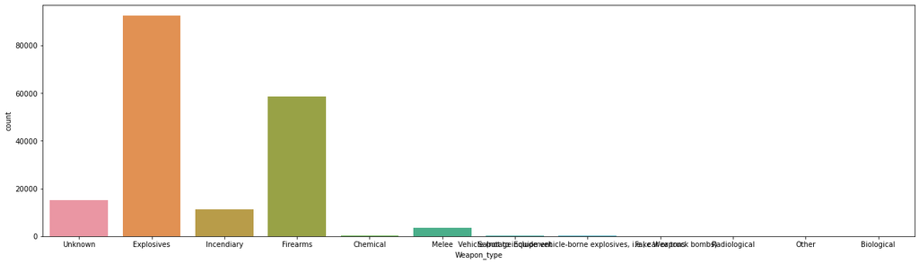

```python
plt.figure(figsize=(22,6));
sns.countplot(x=rm.Weapon_type);
```

**Most of the attacks were attacked through explosives and then through firearms.**

## ATTACKS BY YEAR

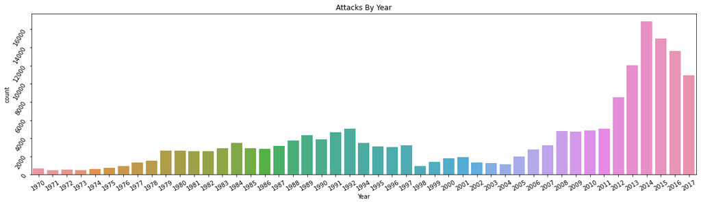

```python
plt.figure(figsize=(20,5));
plt.xticks(rotation =30)
plt.yticks(rotation =60)
plt.title("Attacks By Year")
sns.countplot(x=rm.Year);
```

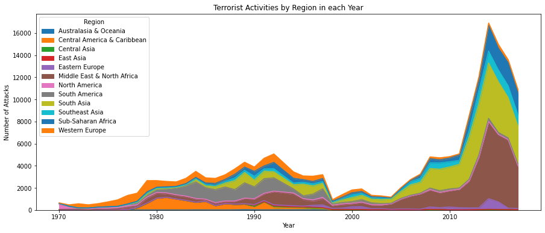

```python
pd.crosstab(rm.Year,rm.Region).plot(kind='area',figsize=(15,6))
plt.title('Terrorist Activities by Region in each Year')
plt.ylabel('Number of Attacks')
plt.show()
```

## ATTACKS BY MONTH

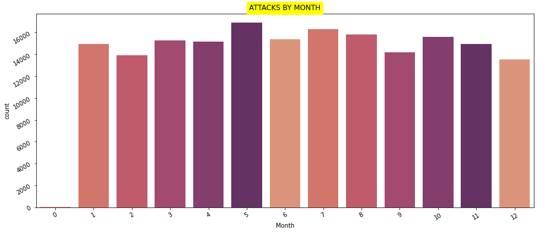

```python
plt.figure(figsize=(15,6));
plt.title('ATTACKS BY MONTH',backgroundcolor='yellow')
plt.xticks(rotation =30,)
plt.yticks(rotation =30,)
sns.countplot(rm['Month'],palette= sns.color_palette("flare"));
```

## ATTACKS BY DAY

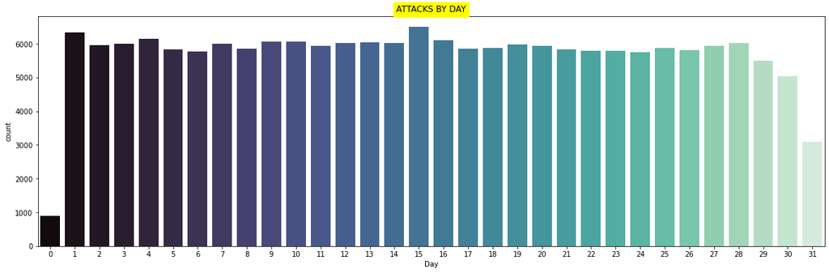

```python
plt.figure(figsize=(20,6));
plt.title('ATTACKS BY DAY',backgroundcolor='yellow')
sns.countplot(x=rm.Day,palette = "mako");
```

## ATTACKS BY COUNTRY

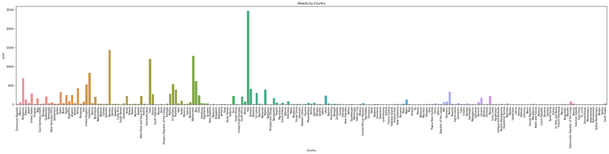

```python
plt.figure(figsize=(35,6));
plt.rcParams.update({'font.size':8});
plt.xticks(rotation = 90)
plt.title('Attacks by Country')
sns.countplot(x=rm.Country);
```

**Iraq dominates all the countries and it has the highest number of attacks and then Pakistan, Afghanistan, and India follow it. Government should increase safety measures in these countries.**

## TARGET TYPES

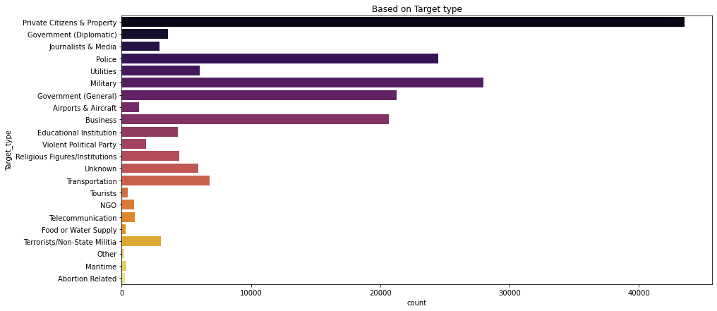

```python
plt.figure(figsize=(15,7));
plt.rcParams.update({'font.size':10});
plt.title('Based on Target type')
sns.countplot(y=rm.Target_type,palette='inferno');
```

For most of the attacks, the target is Private Citizens& property and the next Military leads.

# WEAPON TYPES

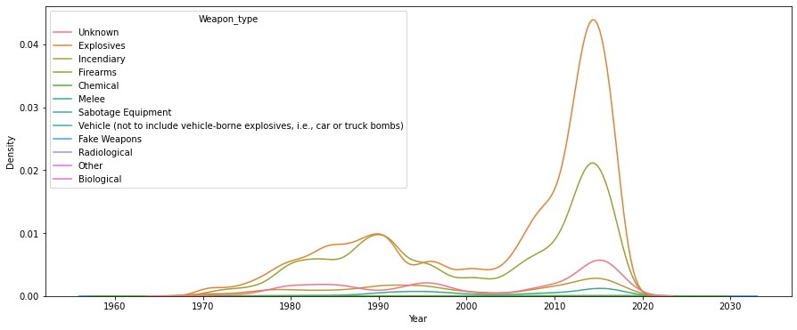

```python
plt.figure(figsize=(15,6));
sns.kdeplot(x='Year' , data=rm, hue='Weapon_type')
```

## ATTACK TYPES

[figure not shown]

```python
atck=[]
[atck.append(x) for x in rm['Attack_type'] if x not in atck]
fig = plt.figure(figsize =(10,18))
explode = (0.1, 0.2, 0.1,0.2,0.2,0.4,0.5,0.7,0.9)
plt.pie(rm['Attack_type'].value_counts(),labels=atck,autopct='%1.2f%%',explode=explode)
plt.legend(title ="ATTACK TYPE",title_fontsize=10,loc ="best",fontsize=10,bbox_to_anchor =(1, 0, 0.5, 1))
plt.show()
```

# RESULTS OF ANALYSIS

#### Most of the attacks were attacked through explosives and then through firearms.

#### Attacks were more during 2014 and then in 2015. When compared to attacks from 1970 onwards, the last 6 years scored a maximum. But from 2014 onwards count started decreasing.

#### Iraq dominates all the countries and it has the highest number of attacks and then Pakistan, Afghanistan, and India follow it.

#### The Middle East& North Africa leads 1st among all the regions and then South Asia takes 2nd place.

#### For most of the attacks, the target is Private Citizens& property and the next Military leads.

# SECURITY ISSUES

#### Government should provide more security over countries.

#### Security should be strengthened across borders.

#### Reduce effect of dangerous weapons.

#### Government should take measures on increased immigration.

# References

https://www.analyticsvidhya.com/blog/2022/03/exploratory-data-analysis-on-terrorism-dataset/